# work 3

DAY 6

```python
import pandas as pd
df=pd.read_csv("cleaned_data.csv")
```

```python
df
```

|  | Unnamed: 0 | country | location_name | latitude | longitude | timezone | last_updated_epoch | last_updated | temperature_celsius | temperature_fahrenheit | ... | moonset | moon_phase | moon_illumination | date | time | continent | city | month | day | year |
| --- | --- | --- | --- | --- | --- | --- | --- | --- | --- | --- | --- | --- | --- | --- | --- | --- | --- | --- | --- | --- | --- |
| 0 | 0 | Afghanistan | Kabul | 34.5200 | 69.1800 | Asia/Kabul | 1715849100 | 2024-05-16 13:15:00 | 26.6 | 79.8 | ... | 1:11 AM | Waxing Gibbous | 55 | 2024-05-16 | 13:15:00 | Asia | Kabul | 5 | 16 | 2024 |
| 1 | 1 | Albania | Tirana | 41.3300 | 19.8200 | Europe/Tirane | 1715849100 | 2024-05-16 10:45:00 | 19.0 | 66.2 | ... | 2:14 AM | Waxing Gibbous | 55 | 2024-05-16 | 10:45:00 | Europe | Tirane | 5 | 16 | 2024 |
| 2 | 2 | Algeria | Algiers | 36.7600 | 3.0500 | Africa/Algiers | 1715849100 | 2024-05-16 09:45:00 | 23.0 | 73.4 | ... | 2:14 AM | Waxing Gibbous | 55 | 2024-05-16 | 09:45:00 | Africa | Algiers | 5 | 16 | 2024 |
| 3 | 3 | Andorra | Andorra La Vella | 42.5000 | 1.5200 | Europe/Andorra | 1715849100 | 2024-05-16 10:45:00 | 6.3 | 43.3 | ... | 3:31 AM | Waxing Gibbous | 55 | 2024-05-16 | 10:45:00 | Europe | Andorra | 5 | 16 | 2024 |
| 4 | 4 | Angola | Luanda | -8.8400 | 13.2300 | Africa/Luanda | 1715849100 | 2024-05-16 09:45:00 | 26.0 | 78.8 | ... | 12:38 AM | Waxing Gibbous | 55 | 2024-05-16 | 09:45:00 | Africa | Luanda | 5 | 16 | 2024 |
| ... | ... | ... | ... | ... | ... | ... | ... | ... | ... | ... | ... | ... | ... | ... | ... | ... | ... | ... | ... | ... | ... |
| 135068 | 135068 | Venezuela | Caracas | 10.5000 | -66.9167 | America/Caracas | 1775975400 | 2026-04-12 02:30:00 | 19.1 | 66.3 | ... | 2:31 PM | Waning Crescent | 31 | 2026-04-12 | 02:30:00 | America | Caracas | 4 | 12 | 2026 |
| 135069 | 135069 | Vietnam | Hanoi | 21.0333 | 105.8500 | Asia/Bangkok | 1775975400 | 2026-04-12 13:30:00 | 34.2 | 93.6 | ... | 1:21 PM | Waning Crescent | 35 | 2026-04-12 | 13:30:00 | Asia | Bangkok | 4 | 12 | 2026 |
| 135070 | 135070 | Yemen | Sanaa | 15.3547 | 44.2067 | Asia/Aden | 1775975400 | 2026-04-12 09:30:00 | 19.3 | 66.7 | ... | 1:45 PM | Waning Crescent | 34 | 2026-04-12 | 09:30:00 | Asia | Aden | 4 | 12 | 2026 |
| 135071 | 135071 | Zambia | Lusaka | -15.4167 | 28.2833 | Africa/Lusaka | 1775975400 | 2026-04-12 08:30:00 | 18.5 | 65.3 | ... | 2:30 PM | Waning Crescent | 33 | 2026-04-12 | 08:30:00 | Africa | Lusaka | 4 | 12 | 2026 |
| 135072 | 135072 | Zimbabwe | Harare | -17.8178 | 31.0447 | Africa/Harare | 1775975400 | 2026-04-12 08:30:00 | 17.4 | 63.3 | ... | 2:22 PM | Waning Crescent | 33 | 2026-04-12 | 08:30:00 | Africa | Harare | 4 | 12 | 2026 |

135073 rows × 49 columns

```python
ind=df[df["country"]=="India"]
ind
```

|  | Unnamed: 0 | country | location_name | latitude | longitude | timezone | last_updated_epoch | last_updated | temperature_celsius | temperature_fahrenheit | ... | moonset | moon_phase | moon_illumination | date | time | continent | city | month | day | year |
| --- | --- | --- | --- | --- | --- | --- | --- | --- | --- | --- | --- | --- | --- | --- | --- | --- | --- | --- | --- | --- | --- |
| 77 | 77 | India | New Delhi | 28.6 | 77.2 | Asia/Kolkata | 1715849100 | 2024-05-16 14:15:00 | 42.0 | 107.6 | ... | 1:30 AM | Waxing Gibbous | 55 | 2024-05-16 | 14:15:00 | Asia | Kolkata | 5 | 16 | 2024 |
| 272 | 272 | India | New Delhi | 28.6 | 77.2 | Asia/Kolkata | 1715868000 | 2024-05-16 19:30:00 | 38.0 | 100.4 | ... | 1:30 AM | Waxing Gibbous | 55 | 2024-05-16 | 19:30:00 | Asia | Kolkata | 5 | 16 | 2024 |
| 467 | 467 | India | New Delhi | 28.6 | 77.2 | Asia/Kolkata | 1715961600 | 2024-05-17 21:30:00 | 36.0 | 96.8 | ... | 1:58 AM | Waxing Gibbous | 64 | 2024-05-17 | 21:30:00 | Asia | Kolkata | 5 | 17 | 2024 |
| 659 | 659 | India | New Delhi | 28.6 | 77.2 | Asia/Kolkata | 1716042600 | 2024-05-18 20:00:00 | 41.0 | 105.8 | ... | 2:24 AM | Waxing Gibbous | 73 | 2024-05-18 | 20:00:00 | Asia | Kolkata | 5 | 18 | 2024 |
| 853 | 853 | India | New Delhi | 28.6 | 77.2 | Asia/Kolkata | 1716128100 | 2024-05-19 19:45:00 | 41.0 | 105.8 | ... | 2:51 AM | Waxing Gibbous | 81 | 2024-05-19 | 19:45:00 | Asia | Kolkata | 5 | 19 | 2024 |
| ... | ... | ... | ... | ... | ... | ... | ... | ... | ... | ... | ... | ... | ... | ... | ... | ... | ... | ... | ... | ... | ... |
| 134175 | 134175 | India | New Delhi | 28.6 | 77.2 | Asia/Kolkata | 1775629800 | 2026-04-08 12:00:00 | 24.2 | 75.6 | ... | 9:49 AM | Waning Gibbous | 72 | 2026-04-08 | 12:00:00 | Asia | Kolkata | 4 | 8 | 2026 |
| 134370 | 134370 | India | New Delhi | 28.6 | 77.2 | Asia/Kolkata | 1775716200 | 2026-04-09 12:00:00 | 27.3 | 81.1 | ... | 10:43 AM | Waning Gibbous | 64 | 2026-04-09 | 12:00:00 | Asia | Kolkata | 4 | 9 | 2026 |
| 134565 | 134565 | India | New Delhi | 28.6 | 77.2 | Asia/Kolkata | 1775803500 | 2026-04-10 12:15:00 | 29.2 | 84.6 | ... | 11:40 AM | Last Quarter | 54 | 2026-04-10 | 12:15:00 | Asia | Kolkata | 4 | 10 | 2026 |
| 134760 | 134760 | India | New Delhi | 28.6 | 77.2 | Asia/Kolkata | 1775889000 | 2026-04-11 12:00:00 | 31.4 | 88.5 | ... | 12:38 PM | Waning Crescent | 45 | 2026-04-11 | 12:00:00 | Asia | Kolkata | 4 | 11 | 2026 |
| 134955 | 134955 | India | New Delhi | 28.6 | 77.2 | Asia/Kolkata | 1775975400 | 2026-04-12 12:00:00 | 31.1 | 88.0 | ... | 1:38 PM | Waning Crescent | 35 | 2026-04-12 | 12:00:00 | Asia | Kolkata | 4 | 12 | 2026 |

692 rows × 49 columns

```python
afgan = df[df["country"]=="Afghanistan"]
afgan
```

|  | Unnamed: 0 | country | location_name | latitude | longitude | timezone | last_updated_epoch | last_updated | temperature_celsius | temperature_fahrenheit | ... | moonset | moon_phase | moon_illumination | date | time | continent | city | month | day | year |
| --- | --- | --- | --- | --- | --- | --- | --- | --- | --- | --- | --- | --- | --- | --- | --- | --- | --- | --- | --- | --- | --- |
| 0 | 0 | Afghanistan | Kabul | 34.5200 | 69.1800 | Asia/Kabul | 1715849100 | 2024-05-16 13:15:00 | 26.6 | 79.8 | ... | 1:11 AM | Waxing Gibbous | 55 | 2024-05-16 | 13:15:00 | Asia | Kabul | 5 | 16 | 2024 |
| 195 | 195 | Afghanistan | Kabul | 34.5200 | 69.1800 | Asia/Kabul | 1715868000 | 2024-05-16 18:30:00 | 22.0 | 71.6 | ... | 1:11 AM | Waxing Gibbous | 55 | 2024-05-16 | 18:30:00 | Asia | Kabul | 5 | 16 | 2024 |
| 390 | 390 | Afghanistan | Kabul | 34.5200 | 69.1800 | Asia/Kabul | 1715961600 | 2024-05-17 20:30:00 | 15.0 | 58.9 | ... | 1:37 AM | Waxing Gibbous | 64 | 2024-05-17 | 20:30:00 | Asia | Kabul | 5 | 17 | 2024 |
| 583 | 583 | Afghanistan | Kabul | 34.5200 | 69.1800 | Asia/Kabul | 1716042600 | 2024-05-18 19:00:00 | 19.5 | 67.1 | ... | 2:00 AM | Waxing Gibbous | 73 | 2024-05-18 | 19:00:00 | Asia | Kabul | 5 | 18 | 2024 |
| 776 | 776 | Afghanistan | Kabul | 34.5200 | 69.1800 | Asia/Kabul | 1716127200 | 2024-05-19 18:30:00 | 16.9 | 62.4 | ... | 2:22 AM | Waxing Gibbous | 81 | 2024-05-19 | 18:30:00 | Asia | Kabul | 5 | 19 | 2024 |
| ... | ... | ... | ... | ... | ... | ... | ... | ... | ... | ... | ... | ... | ... | ... | ... | ... | ... | ... | ... | ... | ... |
| 134098 | 134098 | Afghanistan | Kabul | 34.5167 | 69.1833 | Asia/Kabul | 1775629800 | 2026-04-08 11:00:00 | 5.8 | 42.4 | ... | 9:03 AM | Waning Gibbous | 72 | 2026-04-08 | 11:00:00 | Asia | Kabul | 4 | 8 | 2026 |
| 134293 | 134293 | Afghanistan | Kabul | 34.5167 | 69.1833 | Asia/Kabul | 1775716200 | 2026-04-09 11:00:00 | 10.9 | 51.6 | ... | 9:57 AM | Waning Gibbous | 63 | 2026-04-09 | 11:00:00 | Asia | Kabul | 4 | 9 | 2026 |
| 134488 | 134488 | Afghanistan | Kabul | 34.5167 | 69.1833 | Asia/Kabul | 1775803500 | 2026-04-10 11:15:00 | 14.1 | 57.4 | ... | 10:56 AM | Last Quarter | 54 | 2026-04-10 | 11:15:00 | Asia | Kabul | 4 | 10 | 2026 |
| 134683 | 134683 | Afghanistan | Kabul | 34.5167 | 69.1833 | Asia/Kabul | 1775889000 | 2026-04-11 11:00:00 | 13.9 | 57.0 | ... | 11:57 AM | Waning Crescent | 44 | 2026-04-11 | 11:00:00 | Asia | Kabul | 4 | 11 | 2026 |
| 134878 | 134878 | Afghanistan | Kabul | 34.5167 | 69.1833 | Asia/Kabul | 1775975400 | 2026-04-12 11:00:00 | 15.4 | 59.7 | ... | 1:00 PM | Waning Crescent | 34 | 2026-04-12 | 11:00:00 | Asia | Kabul | 4 | 12 | 2026 |

695 rows × 49 columns

mean,median,std,quantiles,maximum,

```python
df.describe()
```

|  | Unnamed: 0 | latitude | longitude | last_updated_epoch | temperature_celsius | temperature_fahrenheit | wind_mph | wind_kph | wind_degree | pressure_mb | ... | air_quality_nitrogen_dioxide | air_quality_sulphur_dioxide | air_quality_pm2.5 | air_quality_pm10 | air_quality_us-epa-index | air_quality_gb-defra-index | moon_illumination | month | day | year |
| --- | --- | --- | --- | --- | --- | --- | --- | --- | --- | --- | --- | --- | --- | --- | --- | --- | --- | --- | --- | --- | --- |
| count | 135073.000000 | 135073.000000 | 135073.000000 | 1.350730e+05 | 135073.000000 | 135073.000000 | 135073.000000 | 135073.000000 | 135073.000000 | 135073.000000 | ... | 135073.000000 | 135073.000000 | 135073.000000 | 135073.000000 | 135073.000000 | 135073.000000 | 135073.000000 | 135073.000000 | 135073.000000 | 135073.000000 |
| mean | 67536.000000 | 19.208948 | 21.961711 | 1.745908e+09 | 21.283607 | 70.312259 | 8.021764 | 12.913410 | 168.894909 | 1014.069244 | ... | 15.007413 | 10.365922 | 24.211112 | 48.433111 | 1.699200 | 2.605791 | 49.986444 | 6.634694 | 15.727614 | 2024.815174 |
| std | 38992.360792 | 24.416748 | 65.787645 | 1.734686e+07 | 9.699084 | 17.458216 | 7.225402 | 11.624983 | 103.706143 | 10.369057 | ... | 23.723174 | 35.691840 | 36.911798 | 149.473695 | 0.941003 | 2.445307 | 35.022525 | 3.496042 | 8.829851 | 0.662918 |
| min | 0.000000 | -41.300000 | -175.200000 | 1.715849e+09 | -29.800000 | -21.600000 | 2.200000 | 3.600000 | 1.000000 | 947.000000 | ... | 0.000000 | -9999.000000 | 0.168000 | -1848.150000 | 1.000000 | 1.000000 | 0.000000 | 1.000000 | 1.000000 | 2024.000000 |
| 25% | 33768.000000 | 4.050300 | -6.836100 | 1.730970e+09 | 16.000000 | 60.800000 | 3.800000 | 6.100000 | 80.000000 | 1010.000000 | ... | 1.665000 | 1.110000 | 7.050000 | 9.990000 | 1.000000 | 1.000000 | 15.000000 | 3.000000 | 8.000000 | 2024.000000 |
| 50% | 67536.000000 | 17.250000 | 23.236100 | 1.745916e+09 | 24.000000 | 75.200000 | 6.700000 | 10.800000 | 161.000000 | 1014.000000 | ... | 5.550000 | 2.405000 | 14.200000 | 19.980000 | 1.000000 | 2.000000 | 50.000000 | 7.000000 | 16.000000 | 2025.000000 |
| 75% | 101304.000000 | 40.400000 | 49.882200 | 1.760860e+09 | 28.000000 | 82.400000 | 11.000000 | 17.600000 | 256.000000 | 1018.000000 | ... | 17.390000 | 8.325000 | 27.750000 | 41.450000 | 2.000000 | 3.000000 | 85.000000 | 10.000000 | 23.000000 | 2025.000000 |
| max | 135072.000000 | 64.150000 | 179.220000 | 1.775975e+09 | 49.200000 | 120.600000 | 1841.200000 | 2963.200000 | 360.000000 | 3006.000000 | ... | 427.700000 | 521.330000 | 1614.100000 | 6037.290000 | 6.000000 | 10.000000 | 100.000000 | 12.000000 | 31.000000 | 2026.000000 |

8 rows × 34 columns

# mean

```python
df["latitude"].mean()
```

```
np.float64(19.208948125087915)
```

median

```python
df["latitude"].median()
```

```
17.25
```

mode

```python
df["latitude"].mode()
```

```
0    41.9
Name: latitude, dtype: float64
```

```python
df["cloud"].quantile()
```

```
np.float64(31.0)
```

```python
import matplotlib.pyplot as plt
import seaborn as sns
```

AVERAGE TEMPERATURE BY CITIES

compare cities by its temperature ,see which city is hotter or cooler compares to others

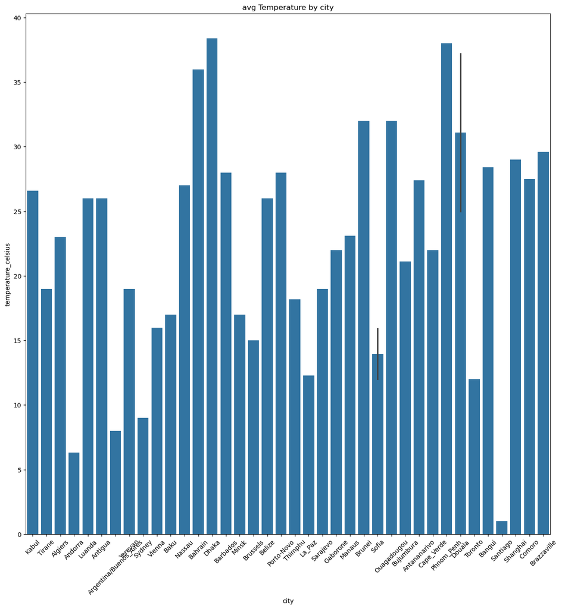

```python
plt.figure(figsize=(15,15))
sns.barplot(x='city',y='temperature_celsius',data=df.head(40))
plt.xticks(rotation=45)
plt.title("avg Temperature by city")
plt.show()
```

TOP 10 HOTTEST CITIES

The Graph shows the 10 cities with the highest average temperature

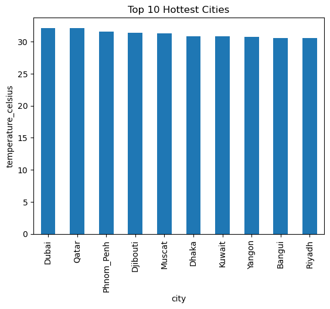

```python
top_cities=df.groupby('city')['temperature_celsius'].mean().sort_values(ascending=False).head(10)
plt.Figure(figsize=(6,4))
top_cities.plot(kind='bar')
plt.xlabel('city')
plt.ylabel('temperature_celsius')
plt.title("Top 10 Hottest Cities")
plt.show()
```

Dubai is the most hottest city then Qatar then so on ,it contain minimal difference between their temperature difference Bangui and Riyadh has least temperature and its temperature are same

TOP 10 COLDEST COUNTRIES

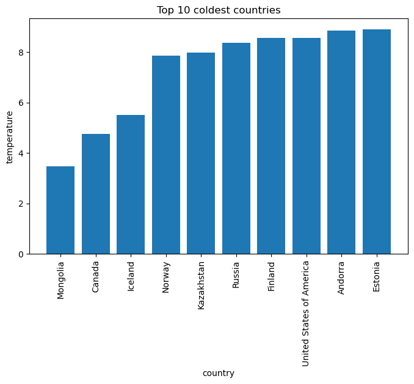

```python
cold10=df.groupby('country')['temperature_celsius'].mean().sort_values().head(10)
plt.figure(figsize=(8,5))
plt.bar(cold10.index,cold10.values)
plt.title("Top 10 coldest countries")
plt.xlabel("country")
plt.ylabel("temperature")
plt.xticks(rotation=90)
plt.show()
```

ESTONIA is the least coldest and mangolia is the most coldest countries,Estonia and Andorra has only minimal difference and Finland and United States of Amarica has almost same 2nd coldest country is canada

MONTHLY TEMPERATURE TRENT

The Graph shows how temperature changes over different month

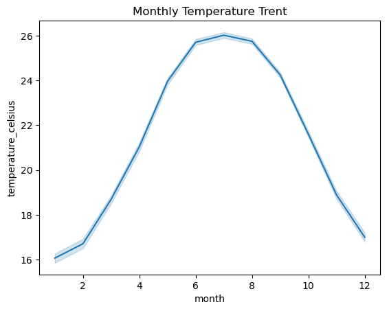

```python
plt.figure()
sns.lineplot(x='month',y='temperature_celsius',data=df)
plt.title("Monthly Temperature Trent")
plt.show()
```

it shows the temperature in different month .the graph shows in the begining low temperature and the middle of the month shows highest temperature and in the end it is low

AVERAGE TEMPERATURE BY COUNTRIES

the graph shows how hot or cold different countries are on average based on the data

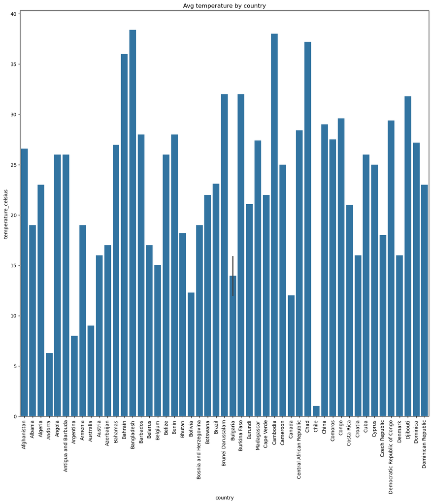

```python
plt.figure(figsize=(15,15))
sns.barplot(x='country',y='temperature_celsius',data=df.head(50))
plt.xticks(rotation=90)
plt.title("Avg temperature by country")
plt.show()
```

least temperature in chile and peak temperature in Bangladesh

TEMPERATURE OVER TIME

A "TEMPERATURE OVER TIME" Graph shows how temperature changes countinuosly accross time(date)

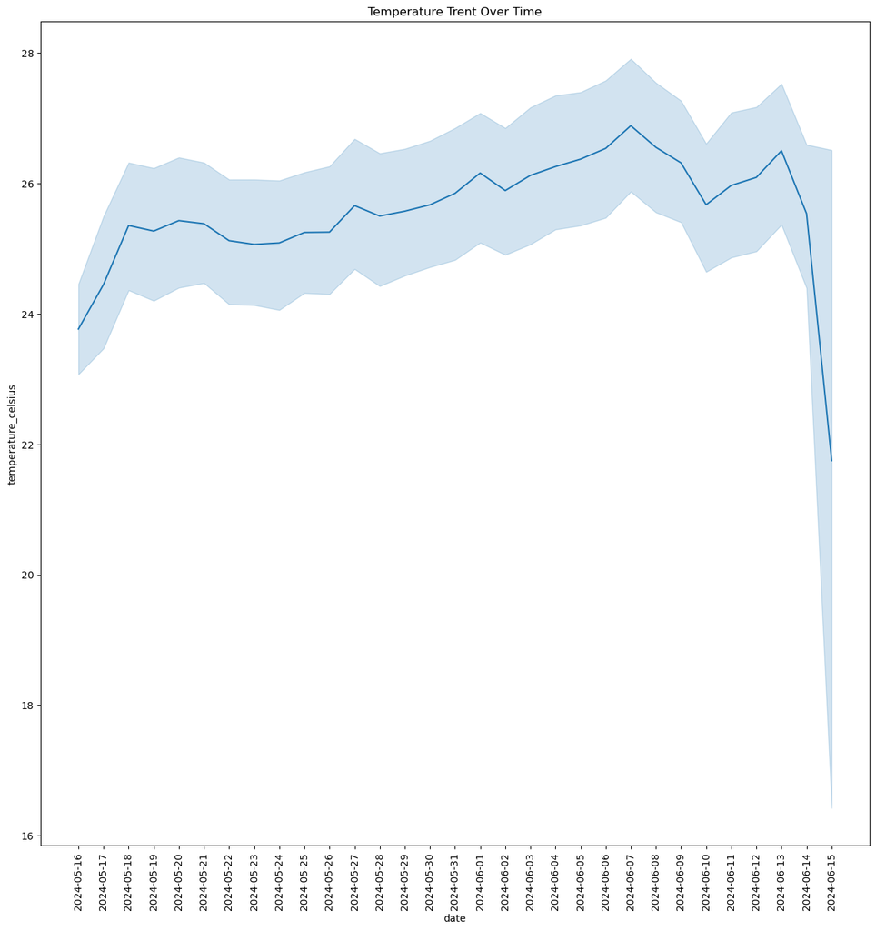

```python
plt.figure(figsize=(15,15))
sns.lineplot(x='date',y='temperature_celsius',data=df.head(6000))
plt.xticks(rotation=90)
plt.title("Temperature Trent Over Time")
plt.show()
```

TEMPERATURE OVER MONTH

this shows how temperature changes for each month across different year

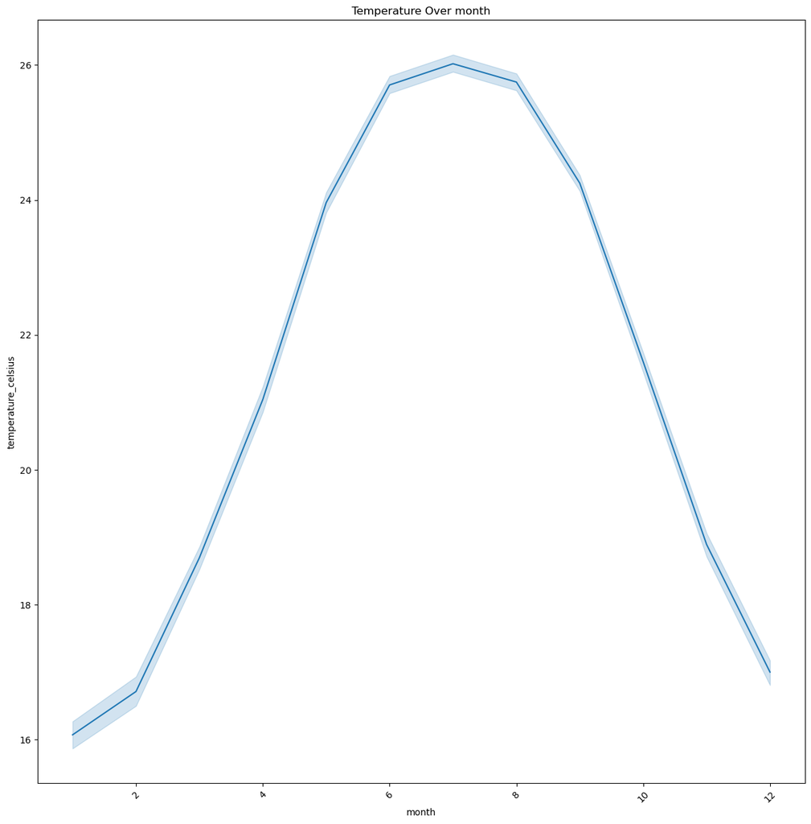

```python
plt.figure(figsize=(15,15))
sns.lineplot(x='month',y='temperature_celsius',data=df)
plt.xticks(rotation=45)
plt.title("Temperature Over month")
plt.show()
```

At beginning of the months temperature is low and in the middle temperature is at peak and also at the end temperature is low

TEMPERATURE IN INDIA

This graph shows how temperature in India changes day by day over time

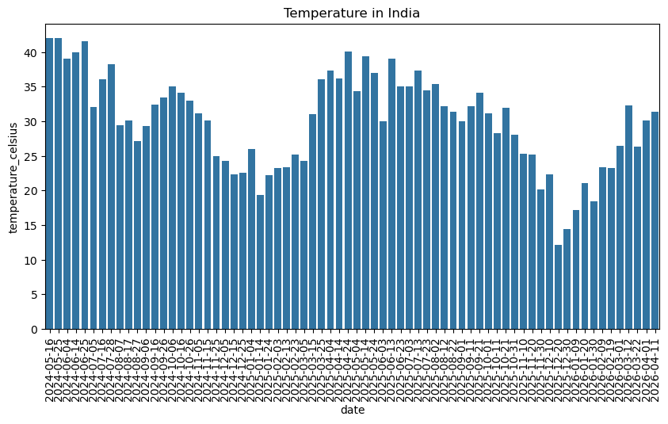

```python
ind_sample=ind.iloc[::10]
plt.figure(figsize=(10,5))
sns.barplot(x='date',y='temperature_celsius',data=ind_sample)
plt.xticks(rotation=90)
plt.title("Temperature in India")
plt.show()
```

In this we can see temperature in india over date highest temperature in 2024 5th month and least temperature in 2025 decemper in this we can seen variations over date

TOP 8 COUNTRIES COMPARISON

Compare top 8 countries based on their data

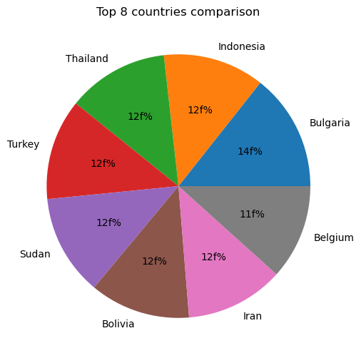

```python
country_data=df['country'].value_counts().head(8)
plt.figure(figsize=(6,6))
plt.pie(country_data,labels=country_data.index,autopct='%1.if%%')
plt.title("Top 8 countries comparison")
plt.show()
```

in this thailand ,bolivia,sudan,iran,turkey,indonesia are same and bulgaria has high and belgium has least

COUNTRIES EXTREME WEATHER CONDITION AT SAME TIME

This graph shows finding different countries experiencing very high or very low temperature at the same date/time

```python
extreme_df=df[(df['temperature_celsius']>40)|(df['temperature_celsius']<0)]
```

```python
same_time=extreme_df.groupby(['date','time'])['country'].unique()
same_time=same_time[same_time.apply(len)>1]
print(same_time.head())
```

```
date        time
2024-05-18  15:30:00             [Chad, Niger]
2024-05-20  15:45:00             [Chad, Niger]
2024-05-21  15:45:00             [Chad, Niger]
2024-05-22  15:15:00             [Chad, Niger]
2024-05-23  17:00:00    [Kuwait, Saudi Arabia]
Name: country, dtype: object
```

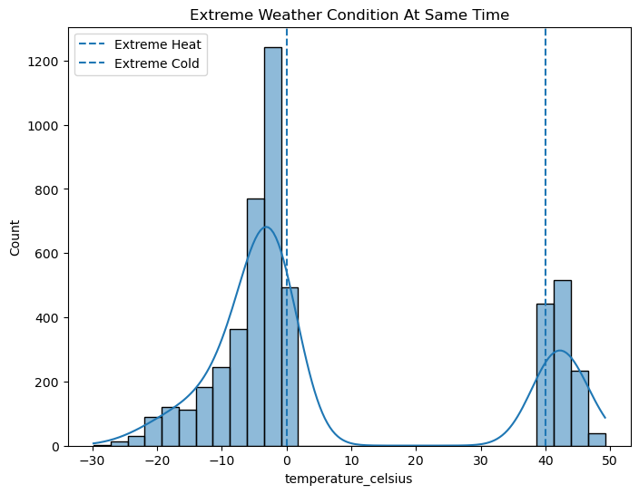

```python
plt.figure(figsize=(8,6))
sns.histplot(extreme_df['temperature_celsius'],bins=30,kde=True)
plt.axvline(40,linestyle='--',label='Extreme Heat')
plt.axvline(0,linestyle='--',label='Extreme Cold')
plt.legend()
plt.title("Extreme Weather Condition At Same Time")
plt.show()
```

there is a clear seperation between these groups,showing that extreme weather condition can occur simultaneously in different part of the world

COMPINE MONTH AND ITS YEAR

```python
df['month_year']=df['month'].astype(str)+'-'+df['year'].astype(str)
```

```python
df
```

|  | Unnamed: 0 | country | location_name | latitude | longitude | timezone | last_updated_epoch | last_updated | temperature_celsius | temperature_fahrenheit | ... | moon_phase | moon_illumination | date | time | continent | city | month | day | year | month_year |
| --- | --- | --- | --- | --- | --- | --- | --- | --- | --- | --- | --- | --- | --- | --- | --- | --- | --- | --- | --- | --- | --- |
| 0 | 0 | Afghanistan | Kabul | 34.5200 | 69.1800 | Asia/Kabul | 1715849100 | 2024-05-16 13:15:00 | 26.6 | 79.8 | ... | Waxing Gibbous | 55 | 2024-05-16 | 13:15:00 | Asia | Kabul | 5 | 16 | 2024 | 5-2024 |
| 1 | 1 | Albania | Tirana | 41.3300 | 19.8200 | Europe/Tirane | 1715849100 | 2024-05-16 10:45:00 | 19.0 | 66.2 | ... | Waxing Gibbous | 55 | 2024-05-16 | 10:45:00 | Europe | Tirane | 5 | 16 | 2024 | 5-2024 |
| 2 | 2 | Algeria | Algiers | 36.7600 | 3.0500 | Africa/Algiers | 1715849100 | 2024-05-16 09:45:00 | 23.0 | 73.4 | ... | Waxing Gibbous | 55 | 2024-05-16 | 09:45:00 | Africa | Algiers | 5 | 16 | 2024 | 5-2024 |
| 3 | 3 | Andorra | Andorra La Vella | 42.5000 | 1.5200 | Europe/Andorra | 1715849100 | 2024-05-16 10:45:00 | 6.3 | 43.3 | ... | Waxing Gibbous | 55 | 2024-05-16 | 10:45:00 | Europe | Andorra | 5 | 16 | 2024 | 5-2024 |
| 4 | 4 | Angola | Luanda | -8.8400 | 13.2300 | Africa/Luanda | 1715849100 | 2024-05-16 09:45:00 | 26.0 | 78.8 | ... | Waxing Gibbous | 55 | 2024-05-16 | 09:45:00 | Africa | Luanda | 5 | 16 | 2024 | 5-2024 |
| ... | ... | ... | ... | ... | ... | ... | ... | ... | ... | ... | ... | ... | ... | ... | ... | ... | ... | ... | ... | ... | ... |
| 135068 | 135068 | Venezuela | Caracas | 10.5000 | -66.9167 | America/Caracas | 1775975400 | 2026-04-12 02:30:00 | 19.1 | 66.3 | ... | Waning Crescent | 31 | 2026-04-12 | 02:30:00 | America | Caracas | 4 | 12 | 2026 | 4-2026 |
| 135069 | 135069 | Vietnam | Hanoi | 21.0333 | 105.8500 | Asia/Bangkok | 1775975400 | 2026-04-12 13:30:00 | 34.2 | 93.6 | ... | Waning Crescent | 35 | 2026-04-12 | 13:30:00 | Asia | Bangkok | 4 | 12 | 2026 | 4-2026 |
| 135070 | 135070 | Yemen | Sanaa | 15.3547 | 44.2067 | Asia/Aden | 1775975400 | 2026-04-12 09:30:00 | 19.3 | 66.7 | ... | Waning Crescent | 34 | 2026-04-12 | 09:30:00 | Asia | Aden | 4 | 12 | 2026 | 4-2026 |
| 135071 | 135071 | Zambia | Lusaka | -15.4167 | 28.2833 | Africa/Lusaka | 1775975400 | 2026-04-12 08:30:00 | 18.5 | 65.3 | ... | Waning Crescent | 33 | 2026-04-12 | 08:30:00 | Africa | Lusaka | 4 | 12 | 2026 | 4-2026 |
| 135072 | 135072 | Zimbabwe | Harare | -17.8178 | 31.0447 | Africa/Harare | 1775975400 | 2026-04-12 08:30:00 | 17.4 | 63.3 | ... | Waning Crescent | 33 | 2026-04-12 | 08:30:00 | Africa | Harare | 4 | 12 | 2026 | 4-2026 |

135073 rows × 50 columns

TEMPERATURE OVER MONTH IN A YEAR

this graph shows how temperature changes month by month in its specific year

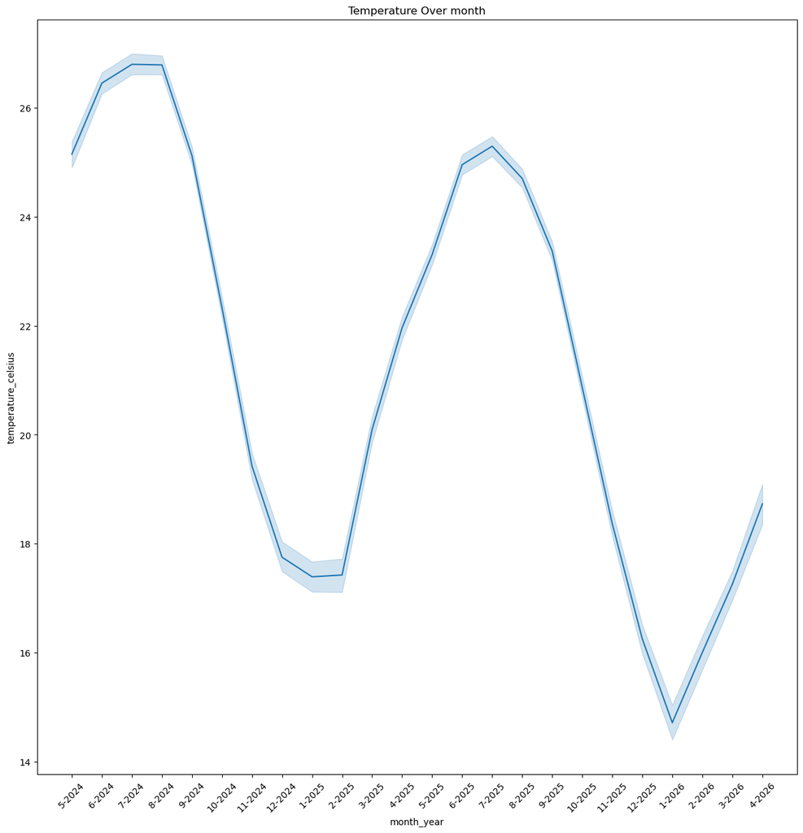

```python
plt.figure(figsize=(15,15))
sns.lineplot(x='month_year',y='temperature_celsius',data=df)
plt.xticks(rotation=45)
plt.title("Temperature Over month")
plt.show()
```

this we can see months with their year in the beginning has highest temperature then it reduse ,it is a same sequence that shows every year almost beginning of the year has least temperarture then it increase

TOP 5 COUNTRIES BY AVERAGE TEMPERATURE

This analysis shows the 5 countries with the highest average temperature in the dataset

```python
country_temp=df.groupby('country')['temperature_celsius'].mean()
```

```python
top5_temp=country_temp.sort_values(ascending=False).head(5)
```

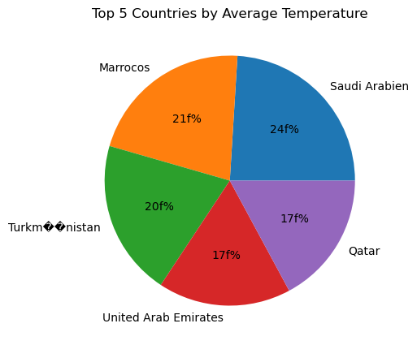

```python
plt.figure(figsize=(5,5))
plt.pie(top5_temp,labels=top5_temp.index,autopct='%1.if%%')
plt.title("Top 5 Countries by Average Temperature")
plt.show()
```

this we can see Saudi Arabien has the highest temperature ,then marrocos has2nd ,etc..we seee the graph Qatar and United Arab Emirates has same

TEMPERATURE VS LATITUDE

A"Temperature Vs Latitude"graph shows the relashionship between how far a place is from the equator and its temperature this graph shows that temperature decreases as we move from the equator

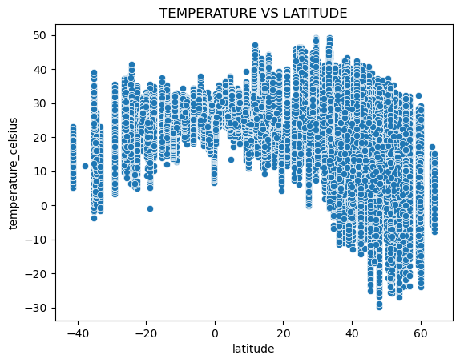

```python
sns.scatterplot(x='latitude',y='temperature_celsius',data=df)
plt.title("TEMPERATURE VS LATITUDE")
plt.figure(figsize=(10,10))
plt.show()
```

TEMPERATURE MAP

This graph shows how temperature is distributed across different location on earth using their geographic position

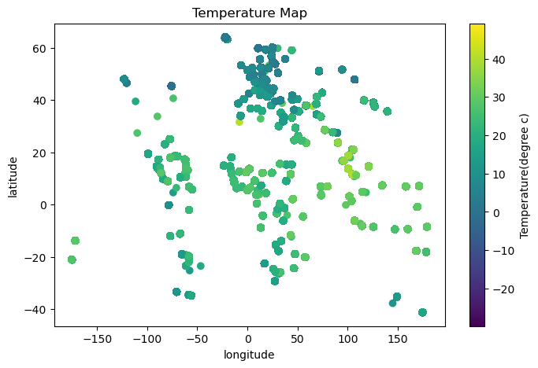

```python
plt.figure(figsize=(8,5))
plt.scatter(df['longitude'],df['latitude'],c=df['temperature_celsius'])
plt.xlabel("longitude")
plt.ylabel("latitude")
plt.title("Temperature Map")
plt.colorbar(label='Temperature(degree c)')
plt.show()
```

temperature is strongly influence by latitude,decreasing as we move away from the equator .longituide has minimal impact on temperature variation.

CORRELATION HEAT MAP

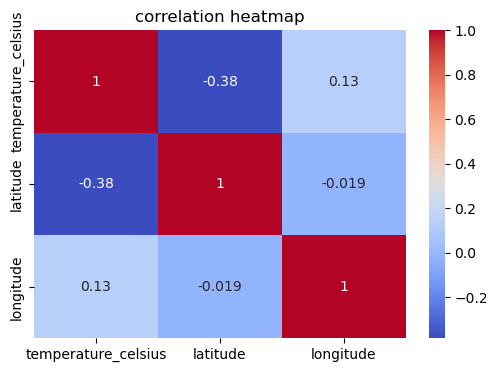

```python
num_df=df[['temperature_celsius','latitude','longitude']]
corr=num_df.corr()
plt.figure(figsize=(6,4))
sns.heatmap(corr,annot=True,cmap='coolwarm')
plt.title("correlation heatmap")
plt.show()
```

longitude has negligible influence on temperature and latitude and longitude are indipendent ,overall latitude is the most important geographic factor affecting temperature in this dataset

```python
import pandas as pd
df=pd.read_csv("GlobalWeatherRepository - GlobalWeatherRepository.csv")
```

```python
df
```

|  | country | location_name | latitude | longitude | timezone | last_updated_epoch | last_updated | temperature_celsius | temperature_fahrenheit | condition_text | ... | air_quality_PM2.5 | air_quality_PM10 | air_quality_us-epa-index | air_quality_gb-defra-index | sunrise | sunset | moonrise | moonset | moon_phase | moon_illumination |
| --- | --- | --- | --- | --- | --- | --- | --- | --- | --- | --- | --- | --- | --- | --- | --- | --- | --- | --- | --- | --- | --- |
| 0 | Afghanistan | Kabul | 34.5200 | 69.1800 | Asia/Kabul | 1715849100 | 2024-05-16 13:15 | 26.6 | 79.8 | Partly Cloudy | ... | 8.40 | 26.60 | 1 | 1 | 4:50 AM | 6:50 PM | 12:12 PM | 1:11 AM | Waxing Gibbous | 55 |
| 1 | Albania | Tirana | 41.3300 | 19.8200 | Europe/Tirane | 1715849100 | 2024-05-16 10:45 | 19.0 | 66.2 | Partly cloudy | ... | 1.10 | 2.00 | 1 | 1 | 5:21 AM | 7:54 PM | 12:58 PM | 2:14 AM | Waxing Gibbous | 55 |
| 2 | Algeria | Algiers | 36.7600 | 3.0500 | Africa/Algiers | 1715849100 | 2024-05-16 9:45 | 23.0 | 73.4 | Sunny | ... | 10.40 | 18.40 | 1 | 1 | 5:40 AM | 7:50 PM | 1:15 PM | 2:14 AM | Waxing Gibbous | 55 |
| 3 | Andorra | Andorra La Vella | 42.5000 | 1.5200 | Europe/Andorra | 1715849100 | 2024-05-16 10:45 | 6.3 | 43.3 | Light drizzle | ... | 0.70 | 0.90 | 1 | 1 | 6:31 AM | 9:11 PM | 2:12 PM | 3:31 AM | Waxing Gibbous | 55 |
| 4 | Angola | Luanda | -8.8400 | 13.2300 | Africa/Luanda | 1715849100 | 2024-05-16 9:45 | 26.0 | 78.8 | Partly cloudy | ... | 183.40 | 262.30 | 5 | 10 | 6:12 AM | 5:55 PM | 1:17 PM | 12:38 AM | Waxing Gibbous | 55 |
| ... | ... | ... | ... | ... | ... | ... | ... | ... | ... | ... | ... | ... | ... | ... | ... | ... | ... | ... | ... | ... | ... |
| 135068 | Venezuela | Caracas | 10.5000 | -66.9167 | America/Caracas | 1775975400 | 2026-04-12 2:30 | 19.1 | 66.3 | Partly Cloudy | ... | 16.35 | 18.15 | 2 | 2 | 6:18 AM | 6:38 PM | 2:36 AM | 2:31 PM | Waning Crescent | 31 |
| 135069 | Vietnam | Hanoi | 21.0333 | 105.8500 | Asia/Bangkok | 1775975400 | 2026-04-12 13:30 | 34.2 | 93.6 | Sunny | ... | 61.15 | 64.45 | 3 | 8 | 5:41 AM | 6:14 PM | 2:02 AM | 1:21 PM | Waning Crescent | 35 |
| 135070 | Yemen | Sanaa | 15.3547 | 44.2067 | Asia/Aden | 1775975400 | 2026-04-12 9:30 | 19.3 | 66.7 | Sunny | ... | 7.45 | 15.35 | 1 | 1 | 5:51 AM | 6:17 PM | 2:06 AM | 1:45 PM | Waning Crescent | 34 |
| 135071 | Zambia | Lusaka | -15.4167 | 28.2833 | Africa/Lusaka | 1775975400 | 2026-04-12 8:30 | 18.5 | 65.3 | Sunny | ... | 5.45 | 6.15 | 1 | 1 | 6:14 AM | 6:01 PM | 1:26 AM | 2:30 PM | Waning Crescent | 33 |
| 135072 | Zimbabwe | Harare | -17.8178 | 31.0447 | Africa/Harare | 1775975400 | 2026-04-12 8:30 | 17.4 | 63.3 | Sunny | ... | 19.85 | 20.55 | 2 | 2 | 6:04 AM | 5:49 PM | 1:10 AM | 2:22 PM | Waning Crescent | 33 |

135073 rows × 41 columns

TOP 10 COUNTRIES WITH WORST AIR QUALITY

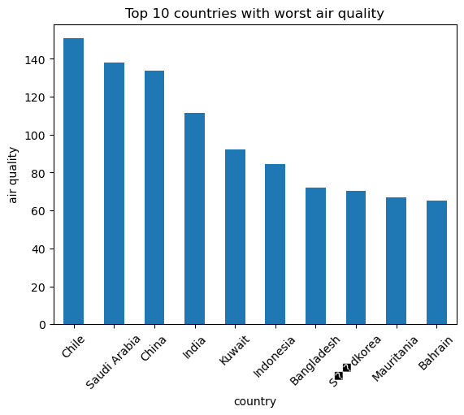

```python
avg_air=df.groupby('country')["air_quality_PM2.5"].mean().sort_values(ascending=False).head(10)
avg_air.plot(kind='bar')
plt.title("Top 10 countries with worst air quality")
plt.xlabel("country")
plt.ylabel("air quality")
plt.xticks(rotation=45)
plt.show()
```

In this we can understand that chile has the most worst air quality least is bahrain .In all countries chile,saudi arabia,china,india,kuwait,indonesia,bangladesh...bahrain is the 10 countries has the worst air quality

TEMPERATURE VS AIR QUALITY

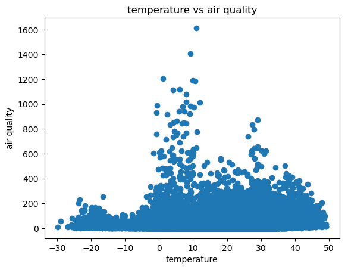

```python
plt.Figure(figsize=(8,5))
plt.scatter(df['temperature_celsius'],df['air_quality_PM2.5'])
plt.xlabel("temperature")
plt.ylabel('air quality')
plt.title("temperature vs air quality")
plt.show()
```

temperature influence air quality but indirectly ,extreme temperature=more stable,less axtreme pollution

1.Which country have the worst air quality?

ans.chile has the most worst air quality least is bahrain .In all countries chile,saudi arabia,china,india,kuwait,indonesia,bangladesh...bahrain is the 10 countries has the worst air quality

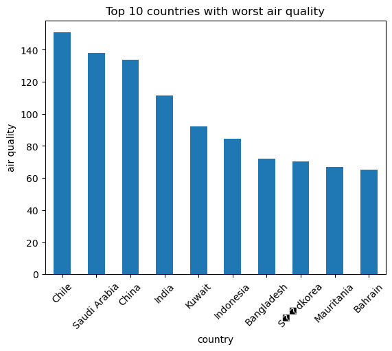

```python
avg_air=df.groupby('country')["air_quality_PM2.5"].mean().sort_values(ascending=False).head(10)
avg_air.plot(kind='bar')
plt.title("Top 10 countries with worst air quality")
plt.xlabel("country")
plt.ylabel("air quality")
plt.xticks(rotation=45)
plt.show()
```

2.How does temperature affect air pollution level?

ans.temperature influence air quality but indirectly ,extreme temperature=more stable,less axtreme pollution

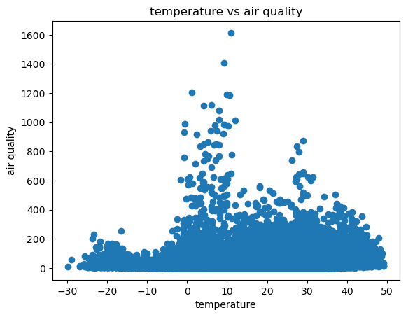

```python
plt.Figure(figsize=(8,5))
plt.scatter(df['temperature_celsius'],df['air_quality_PM2.5'])
plt.xlabel("temperature")
plt.ylabel('air quality')
plt.title("temperature vs air quality")
plt.show()
```

3.which region have extreme weather condition at the same time?

ans.there is a clear seperation between these groups,showing that extreme weather condition can occur simultaneously in different part of the world

```python
extreme_df=df[(df['temperature_celsius']>40)|(df['temperature_celsius']<0)]
```

```python
same_time=extreme_df.groupby(['date','time'])['country'].unique()
same_time=same_time[same_time.apply(len)>1]
print(same_time.head())
```

[output not shown]

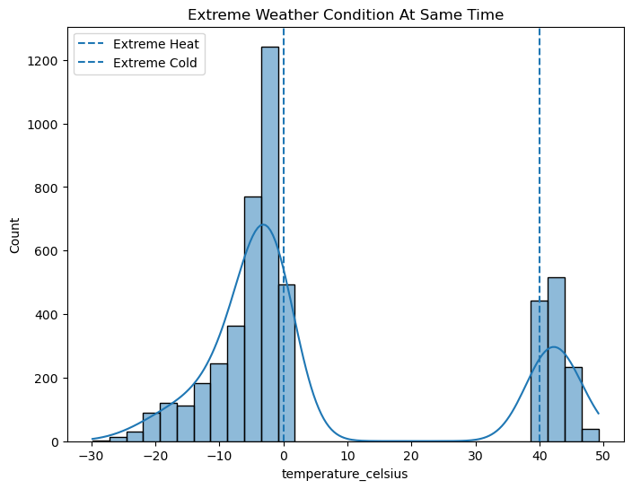

```python
plt.figure(figsize=(8,6))
sns.histplot(extreme_df['temperature_celsius'],bins=30,kde=True)
plt.axvline(40,linestyle='--',label='Extreme Heat')
plt.axvline(0,linestyle='--',label='Extreme Cold')
plt.legend()
plt.title("Extreme Weather Condition At Same Time")
plt.show()
```

4.How does latitude affect temperature?

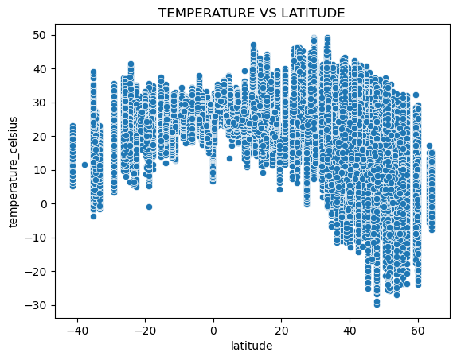

```python
sns.scatterplot(x='latitude',y='temperature_celsius',data=df)
plt.title("TEMPERATURE VS LATITUDE")
plt.figure(figsize=(10,10))
plt.show()
```

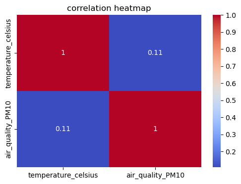

```python
num_df=df[['temperature_celsius','air_quality_PM10']]
corr=num_df.corr()
plt.figure(figsize=(6,4))
sns.heatmap(corr,annot=True,cmap='coolwarm')
plt.title("correlation heatmap")
plt.show()
```